# Practical Machine Learning Course Project

```r
library(caret)
library(rpart)
library(randomForest)
```

```r
training_data_url <- "https://d396qusza40orc.cloudfront.net/predmachlearn/pml-training.csv"
testing_data_url <- "https://d396qusza40orc.cloudfront.net/predmachlearn/pml-testing.csv"
```

```r
training_data <- read.csv(url(training_data_url ))
testing_data <- read.csv(url(testing_data_url ))
```

```r
dim(training_data)
```

```
## [1] 19622   160
```

```r
dim(testing_data)
```

```
## [1]  20 160
```

# Data Cleaning

analyze the table

```r
head(training_data)
```

```
##   X user_name raw_timestamp_part_1 raw_timestamp_part_2   cvtd_timestamp
## 1 1  carlitos           1323084231               788290 05/12/2011 11:23
## 2 2  carlitos           1323084231               808298 05/12/2011 11:23
## 3 3  carlitos           1323084231               820366 05/12/2011 11:23
## 4 4  carlitos           1323084232               120339 05/12/2011 11:23
## 5 5  carlitos           1323084232               196328 05/12/2011 11:23
## 6 6  carlitos           1323084232               304277 05/12/2011 11:23
##   new_window num_window roll_belt pitch_belt yaw_belt total_accel_belt
## 1         no         11      1.41       8.07    -94.4                3
## 2         no         11      1.41       8.07    -94.4                3
## 3         no         11      1.42       8.07    -94.4                3
## 4         no         12      1.48       8.05    -94.4                3
## 5         no         12      1.48       8.07    -94.4                3
## 6         no         12      1.45       8.06    -94.4                3
##   kurtosis_roll_belt kurtosis_picth_belt kurtosis_yaw_belt skewness_roll_belt
```

[output cut: 251 more lines]

```r
nzv <- nearZeroVar(training_data)

#removing near zero valriable from dataset
train_data <- training_data[,-nzv]
test_data <- testing_data[,-nzv]
```

```r
dim(train_data)
```

```
## [1] 19622   100
```

```r
dim(test_data)
```

```
## [1]  20 100
```

By removing near zero variable, we reduce 60 predictors.

Removing NA values from dataset

```r
na_value_column <- sapply(train_data, function(x) mean(is.na(x))) > 0.95

train_data <- train_data[,na_value_column == FALSE]
test_data <- test_data[,na_value_column == FALSE]
```

```r
dim(train_data)
```

```
## [1] 19622    59
```

```r
dim(test_data)
```

```
## [1] 20 59
```

By removing NA values, we reduce 41 predictors.

```r
head(train_data)
```

```
##   X user_name raw_timestamp_part_1 raw_timestamp_part_2   cvtd_timestamp
## 1 1  carlitos           1323084231               788290 05/12/2011 11:23
## 2 2  carlitos           1323084231               808298 05/12/2011 11:23
## 3 3  carlitos           1323084231               820366 05/12/2011 11:23
## 4 4  carlitos           1323084232               120339 05/12/2011 11:23
## 5 5  carlitos           1323084232               196328 05/12/2011 11:23
## 6 6  carlitos           1323084232               304277 05/12/2011 11:23
##   num_window roll_belt pitch_belt yaw_belt total_accel_belt gyros_belt_x
## 1         11      1.41       8.07    -94.4                3         0.00
## 2         11      1.41       8.07    -94.4                3         0.02
## 3         11      1.42       8.07    -94.4                3         0.00
## 4         12      1.48       8.05    -94.4                3         0.02
## 5         12      1.48       8.07    -94.4                3         0.02
## 6         12      1.45       8.06    -94.4                3         0.02
##   gyros_belt_y gyros_belt_z accel_belt_x accel_belt_y accel_belt_z
```

[output cut: 69 more lines]

all NA values were removed

So we will remove them

```r
train_data<- train_data[, 8:59]
test_data<- test_data[, 8:59]
```

```r
dim(train_data)
```

```
## [1] 19622    52
```

```r
dim(test_data)
```

```
## [1] 20 52
```

at the end of cleaning we get 52 predictors out of 160.

# Data Partition

Now, we will part “trai_data” into 2 parts  
* training data(60%)  
* testing data(40%)

```r
inTrain<- createDataPartition(train_data$classe, p=0.6, list=FALSE)
training<- train_data[inTrain,]
testing<- train_data[-inTrain,]
```

```r
dim(training)
```

```
## [1] 11776    52
```

```r
dim(testing)
```

```
## [1] 7846   52
```

# Model Construction

## Decision Tree

```r
library(rattle)
```

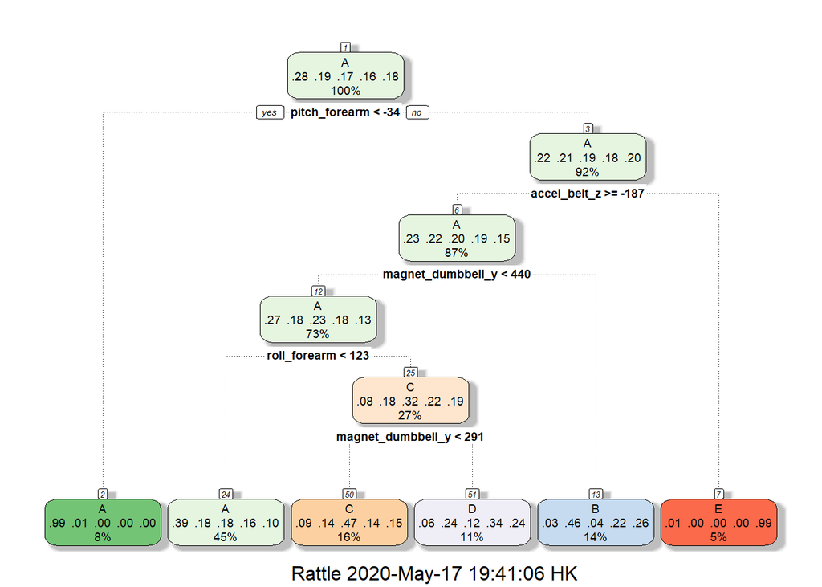

```r
DT_model <- train(classe ~ . , data = training , method = "rpart")

fancyRpartPlot(DT_model$finalModel)
```

Now, We will predict on testing data and observe the output

```r
#Prediction
DT_prediction<- predict(DT_model, testing)
confusionMatrix(table(DT_prediction, testing$classe))
```

```
## Confusion Matrix and Statistics
##
##
## DT_prediction    A    B    C    D    E
##             A 2039  622  638  580  342
##             B   36  529   43  211  279
##             C  110  152  589  198  188
##             D   47  215   98  297  214
##             E    0    0    0    0  419
##
## Overall Statistics
##
##                Accuracy : 0.4936
##                  95% CI : (0.4825, 0.5048)
##     No Information Rate : 0.2845
##     P-Value [Acc > NIR] : < 2.2e-16
##
##                   Kappa : 0.3375
##
##  Mcnemar's Test P-Value : < 2.2e-16
##
## Statistics by Class:
##
##                      Class: A Class: B Class: C Class: D Class: E
## Sensitivity            0.9135  0.34848  0.43056  0.23095   0.2906
## Specificity            0.6113  0.91008  0.89997  0.91250   1.0000
## Pos Pred Value         0.4831  0.48179  0.47615  0.34099   1.0000
## Neg Pred Value         0.9468  0.85344  0.88213  0.85821   0.8623
## Prevalence             0.2845  0.19347  0.17436  0.16391   0.1838
## Detection Rate         0.2599  0.06742  0.07507  0.03785   0.0534
## Detection Prevalence   0.5380  0.13994  0.15766  0.11101   0.0534
## Balanced Accuracy      0.7624  0.62928  0.66526  0.57172   0.6453
```

So we will apply another method

## Random Forest

```r
#Fit the model
RF_model<- train(classe ~. , data=training, method= "rf", ntree=100)
```

```r
#Prediction
RF_prediction<- predict(RF_model, testing)
```

```r
RF_cm<-confusionMatrix(table(RF_prediction, testing$classe))
RF_cm
```

```
## Confusion Matrix and Statistics
##
##
## RF_prediction    A    B    C    D    E
##             A 2229    8    0    0    0
##             B    3 1506   12    0    0
##             C    0    3 1352   22    3
##             D    0    1    4 1260    3
##             E    0    0    0    4 1436
##
## Overall Statistics
##
##                Accuracy : 0.992
##                  95% CI : (0.9897, 0.9938)
##     No Information Rate : 0.2845
##     P-Value [Acc > NIR] : < 2.2e-16
##
##                   Kappa : 0.9898
##
##  Mcnemar's Test P-Value : NA
##
## Statistics by Class:
##
##                      Class: A Class: B Class: C Class: D Class: E
## Sensitivity            0.9987   0.9921   0.9883   0.9798   0.9958
## Specificity            0.9986   0.9976   0.9957   0.9988   0.9994
## Pos Pred Value         0.9964   0.9901   0.9797   0.9937   0.9972
## Neg Pred Value         0.9995   0.9981   0.9975   0.9960   0.9991
## Prevalence             0.2845   0.1935   0.1744   0.1639   0.1838
## Detection Rate         0.2841   0.1919   0.1723   0.1606   0.1830
## Detection Prevalence   0.2851   0.1939   0.1759   0.1616   0.1835
## Balanced Accuracy      0.9986   0.9949   0.9920   0.9893   0.9976
```

# Conclusion

we conclude that, Random Forest is accurate than Decision Tree and get upto 99% of accuracy level.

Now, We will test on “test_data” which is “Out of Sample”

```r
prediction_test<- predict(RF_model, test_data)
prediction_test
```

```
##  [1] B A B A A E D B A A B C B A E E A B B B
## Levels: A B C D E
```